# Exploring data graphically

#### Challenge

> 1. Find out how to change the x-axis to be log-scaled. Search online for how to change the scale of a matplotlib axes object. Remember that seaborn plots return matplotlib axes objects, so all matplotlib function to modify the axes will work on this plot. Good sites to use are the documentation pages for the respective package, and stackoverflow. However, it is often the fastest to type in a well chosen query in your favorite search engine.
> 2. In the logged plot, color the dots according to the region of the observation.

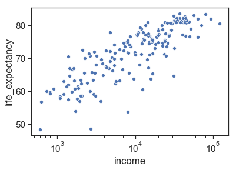

```python
# Challenge solutions
# 1.
ax = sns.scatterplot(x='income', y='life_expectancy', data=world_data_2014)
ax.set_xscale('log')
```

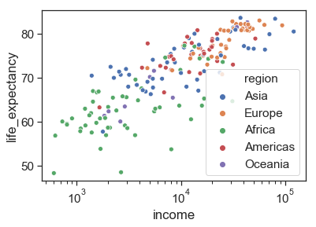

```python
# Challenge solutions
# 2.
ax = sns.scatterplot(x='income', y='life_expectancy', data=world_data_2014, hue='region')
ax.set_xscale('log')
```

Another interesting relationship we could see from the `pairplot` is how child mortality relates to how many children are born per woman. We can filter out years of the data and look at how the relationship has changed over time using the same approach as for the CO2 data.

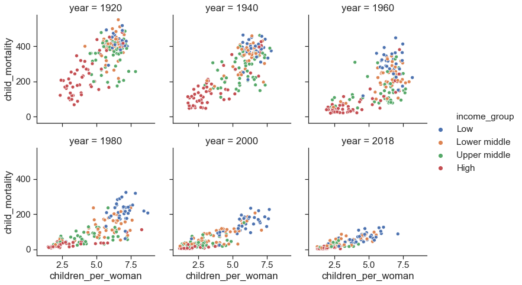

```python
world_data_1920_2018 = world_data.loc[world_data['year'].isin([1920, 1940, 1960, 1980, 2000, 2018])]

sns.relplot(x='children_per_woman', y='child_mortality', col='year', hue='income_group',
            data=world_data_1920_2018, col_wrap=3, height=3.5)
```

A common misconception is that saving poor children will lead to overpopulation. However, we can see that lower child mortality is correlated with smaller family sizes. As more children survive, parents feel more secure with a smaller family size. Reducing poverty is also related to these variables, since most high income countries are found in the lower left corner of the plots (remember that the income group is classified based on 2018 year's income and not for each year that is being plotted above).

It is important to note that from a plot like this, it is not possible to tell causation, just correlation. However, in the [gapminder video library](https://www.gapminder.org/videos/) there are a few videos on this topic (including [this](https://www.gapminder.org/answers/will-saving-poor-children-lead-to-overpopulation/) and [this one](https://www.gapminder.org/videos/population-growth-explained-with-ikea-boxes/)), discussing how reducing poverty can help slow down population growth through decreased family sizes. Current estimates suggest that the word population will stabilize around 11 billion people and the average number of children per woman will be close to two worldwide in year 2100.

### Exploring a single quantitative variable across multiple levels of a categorical variable

When exploring a single quantitative variable, we can choose between plotting every data point (e.g. categorical scatterplots such as swarm plots and strip plots), an approximation of the distribution (e.g. histograms and violinplots), or distribution statistics such as measures of central tendency (e.g. boxplots and barplots).

A good place to start is to visualize the variable's distribution with `distplot()`. Let's look at life expectancy during 2018 using this technique.

```python
world_data_2018 = world_data.loc[world_data['year'] == 2018]
sns.distplot(world_data_2018['life_expectancy'])
```

[output not shown]

`distplot()` can be customized to increase the number of bins and the bandwidth of the kernel. These are both calculated according to heuristics for what should be good numbers for the underlying data, but it is good to know how to change them.

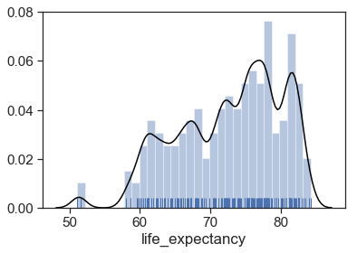

```python
sns.distplot(world_data_2018['life_expectancy'], bins=30, rug=True,
             kde_kws={'bw':1, 'color':'black'})
```

The rug plot along the x-axis shows exactly where each data point resides. To compare distributions between values of a categorical variables, violinplots are often used. These consist of two KDEs mirrored across a midline.

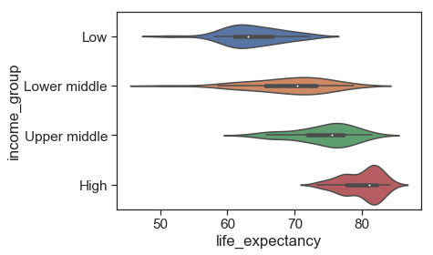

```python
sns.violinplot(x='life_expectancy', y='income_group', data=world_data_2018)
```

Since `income_group` was defined as an ordered categorical variable previously, this order is preserved when distributing the income groups along the y-axis.

There is notable variation in life expectancy between income groups, people in wealthier countries live longer. This variation contributes to the multimodality seen in the first distribution plot of the life expectancy for all countries in the world. However, there is also large overlap between income groups and variation within the groups, so there are more variables affecting the life expectancy than just the income.

Dissecting multimodal distributions in this manner to find underlying explaining variables to why a distribution appears to consist of many small distributions is common practice during EDA. It looks like some income groups, e.g. "high", still consist of multimodal distributions. To explore these further, facetting can be used just as previously. The categorical equivalent of `relplot` is `catplot` (categorical plot).

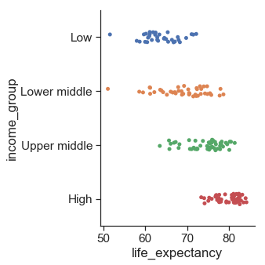

```python
sns.catplot(x='life_expectancy', y='income_group', data=world_data_2018)
```

The default in `catplot` is to create a `stripplot`, a categorical scatterplot where the dots are randomly jittered to not overlap. This is fast to create, but it is sometimes hard to see how many dots are in a group due to overlap. A more ordered approach is to create another type of categorical scatterplot, called swarmplot, where the dots are positioned to avoid overlap.

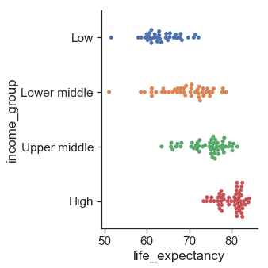

```python
sns.catplot(x='life_expectancy', y='income_group', data=world_data_2018, kind='swarm')
```

The swarm plot communicates the shape of the distribution more clearly than the stripplot, Here, we can see the same bimodality in the high income group as seen in the violinplot, which was hard to see in the stripplot.

A drawback is that swarmplots can be slow to create for large datasets. For really large datasets, even stripplot is slow and it is necessary to approximate the distributions (e.g. with a violinplot) or show distribution statistics (e.g. with a boxplot), instead of showing each observation .

We can use color to find out if regional differences are related to income level.

```python
# TODO Will update this to look prettier
sns.catplot(x='life_expectancy', y='region', data=world_data_2014, kind='box',
            col='income_group', col_wrap=2)
```

[output not shown]

```python
# If both columns can be interpreted as numerical,
# the `orient` keyword can be added to be explicit
sns.catplot(x='life_expectancy', y='year', orient='horizontal', data=world_data_1920_2018, kind='violin',
            col='region', col_wrap=3, color='lightgrey')
```

[output not shown]

Let's explore how much of the variation during the transition in African life expectancy can be explained by geographically close regions performing differently. First how many sub_regions are there in each Africa.

```python
world_data_1920_2018.groupby('region')['sub_region'].nunique()
```

```
region
Africa      2
Americas    2
Asia        5
Europe      4
Oceania     4
Name: sub_region, dtype: int64
```

There are two subregions, let's find out which ones.

```python
world_data_1920_2018.groupby('region')['sub_region'].unique()
```

```
region
Africa                  [Northern Africa, Sub-Saharan Africa]
Americas    [Latin America and the Caribbean, Northern Ame...
Asia        [Southern Asia, Western Asia, South-eastern As...
Europe      [Southern Europe, Western Europe, Eastern Euro...
Oceania     [Australia and New Zealand, Melanesia, Microne...
Name: sub_region, dtype: object
```

Let's see if sub-saharan and northern Africa have had different development when it comes to life expectancy.

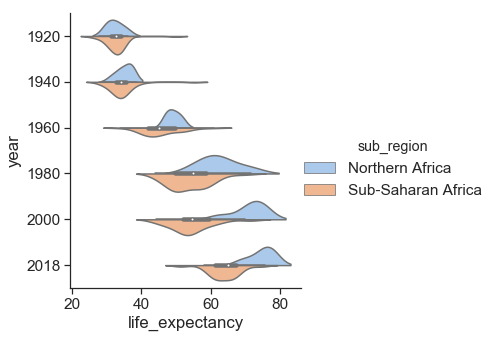

```python
# The split parameter saves some space and looks slick
africa = world_data_1920_2018.loc[world_data_1920_2018['region'] == 'Africa']
sns.catplot(x='life_expectancy', y='year', orient='horizontal', data=africa, kind='violin',
            hue='sub_region', palette='pastel', split=True)
```

For the last challenge, we will explore how an education indicator between and men and women varies.

```python
world_data.dropna(subset=['years_in_school_women'])['year'].agg(['min', 'max'])
```

```
min    1970
max    2015
Name: year, dtype: int64
```

#### Challenge

> 1. Subset dataframe for the years 1975, 1995, and 2015
> 2. Make a new column of ratio women men in education
> 3. plot for regions and income groups and times (reword)

```python
# Challenge solutions
# 1.
world_data_1970_2015 = world_data.loc[world_data['year'].isin([1975, 1995, 2015])].copy()
```

```python
# 2.
world_data_1970_2015['women_men_school_ratio'] = world_data_1970_2015['years_in_school_women'] / world_data_1970_2015['years_in_school_men']
# world_data_1970_2015['women_men_school_ratio']
```

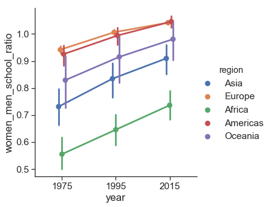

```python
# 3a.
sns.catplot(y='women_men_school_ratio', x='year', data=world_data_1970_2015, hue='region', dodge=True, kind='point')
```

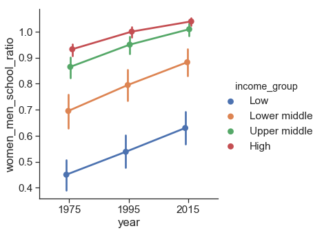

```python
# 3b.
sns.catplot(y='women_men_school_ratio', x='year', data=world_data_1970_2015, hue='income_group', dodge=True, kind='point')
```